# ch.05 Mathematical Models for Network Graphs

Park, Jung Eun

Friday, March 27, 2015

encoding : EUC-KR setwd(“D:/1409_DataVisualization/14DV_part3/Network/ch05_PJE”)

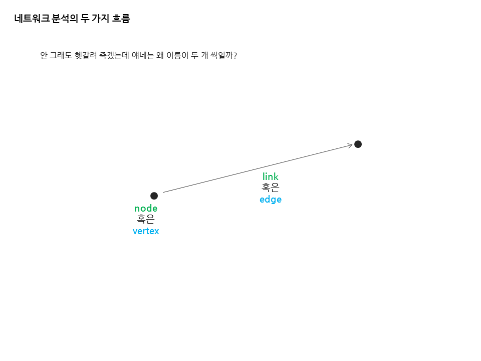

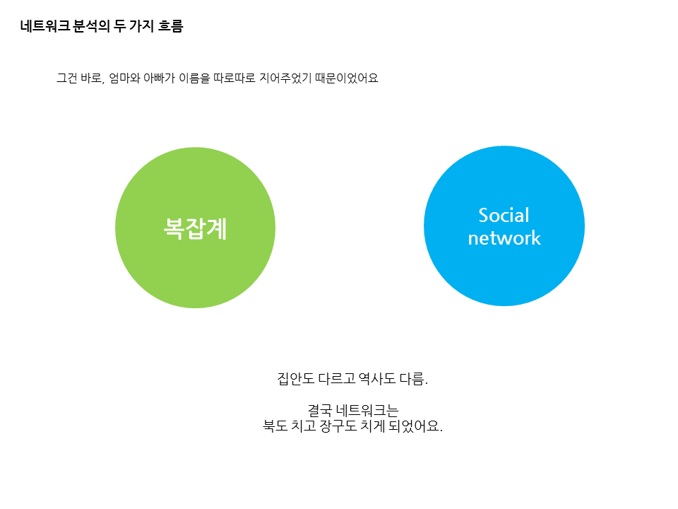

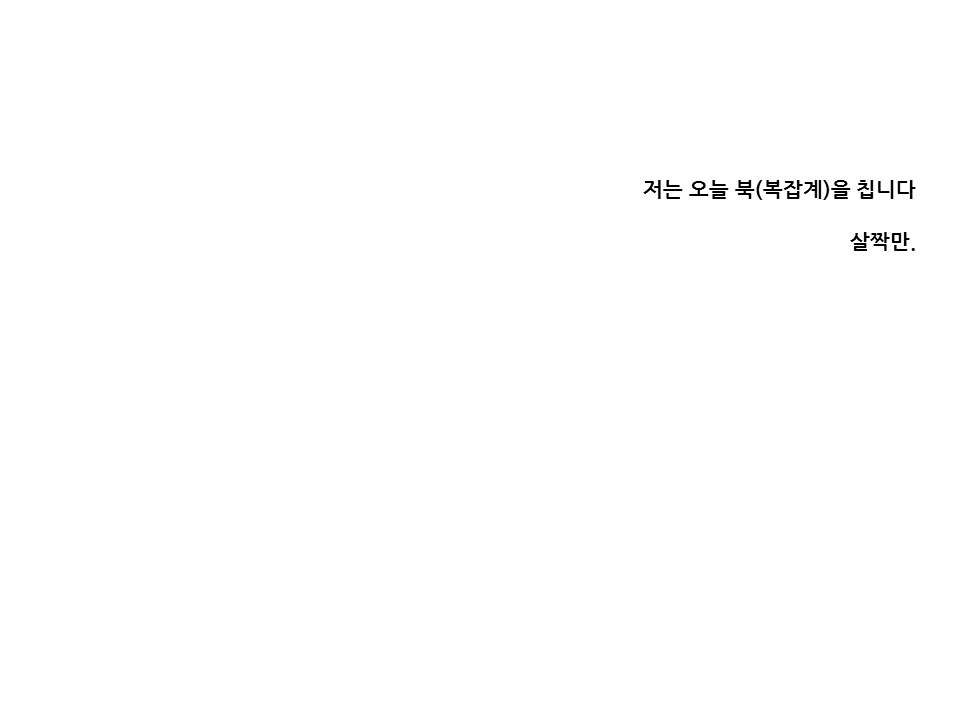

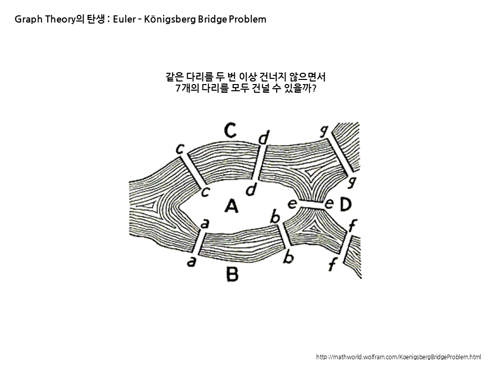

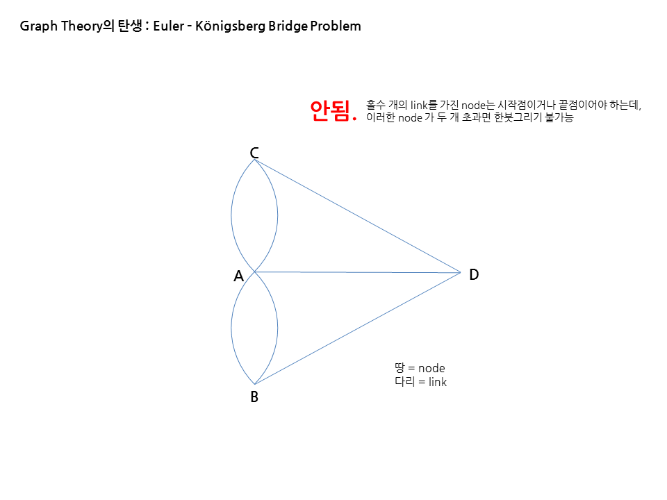

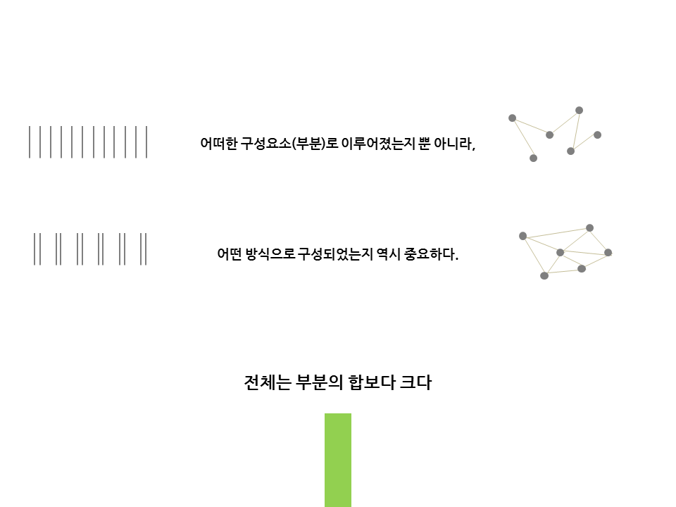

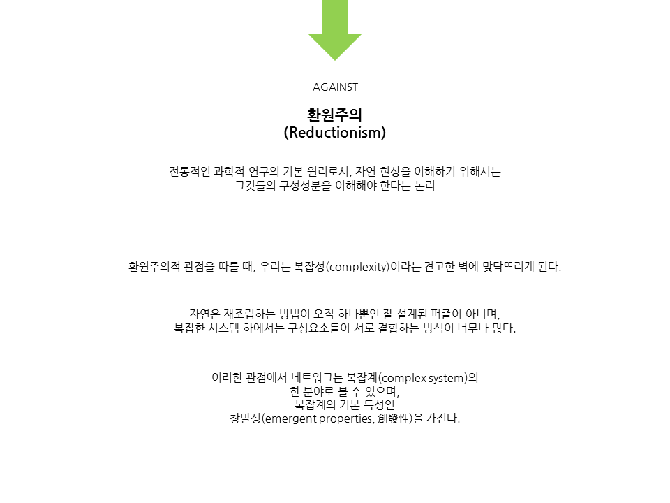

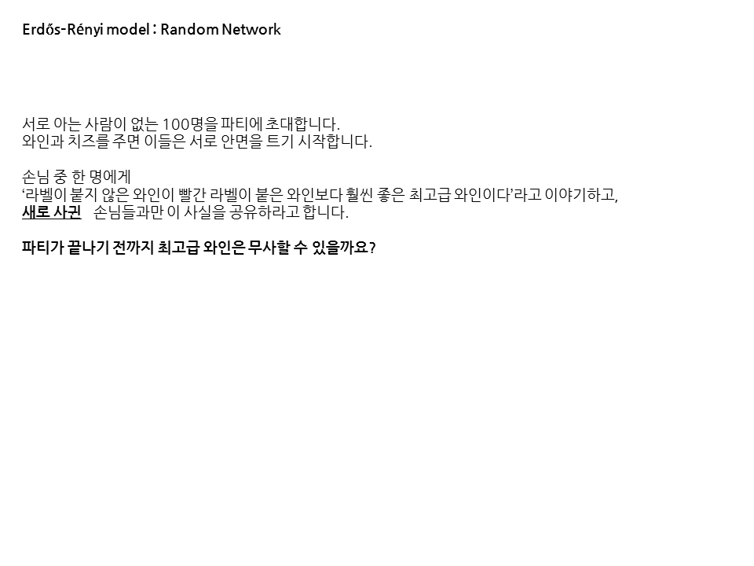

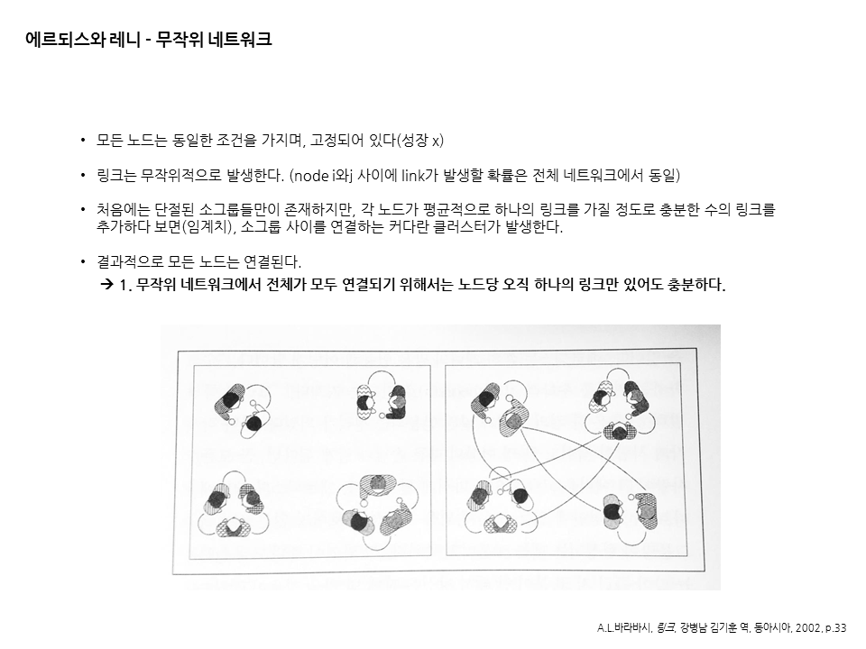

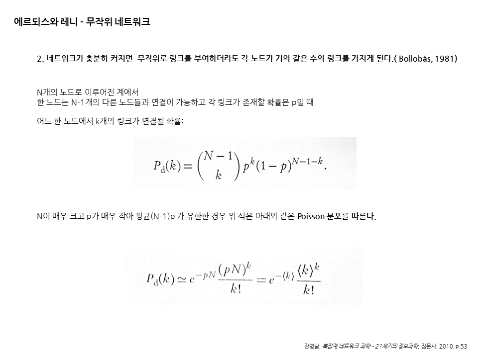

5.2 Classical Random Graph Models

- Link가 존재할 확률이 p, node가 N개인 네트워크에서,
- 임의의 node I,j 를 골라 link가 없으면 p의 확률로 link를 생성하고, link가 있으면 다시 다른 두 개의 node를 골라 이 과정을 반복한다.
- R Code : erdos.renyi.game(N,p)

```r
library(sand)
```

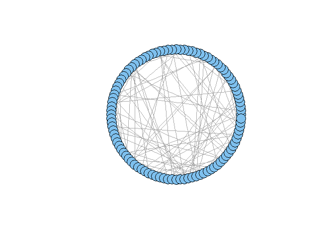

```r
set.seed(42)

#100개의 vertex와 95개의 link를 가진 에르되스-레니 그래프 생성
g.er <- erdos.renyi.game(100,0.02)
plot(g.er, layout = layout.circle, vertex.label=NA)
```

```r
str(g.er)
```

```
## IGRAPH U--- 100 95 -- Erdos renyi (gnp) graph
## + attr: name (g/c), type (g/c), loops (g/l), p (g/n)
## + edges:
##  [1]  4--  6  1--  9 14-- 15  6-- 19 14-- 19  7-- 24 27-- 28 18-- 29
##  [9] 26-- 31 15-- 32 25-- 32 29-- 37 24-- 38 35-- 39 34-- 43 30-- 45
## [17]  2-- 46 18-- 46  7-- 48 19-- 49 25-- 49 36-- 50 41-- 50 51-- 52
## [25] 43-- 60 46-- 60 59-- 60 38-- 62  1-- 63 15-- 63 46-- 63 15-- 64
## [33] 26-- 64 37-- 65  4-- 67 28-- 67 56-- 67 38-- 69 66-- 69  5-- 70
## [41] 59-- 70 11-- 71 65-- 73  1-- 74  4-- 74 37-- 74 30-- 75 37-- 76
## [49] 70-- 76  7-- 77 39-- 77 30-- 78 14-- 79 16-- 79 43-- 79 47-- 79
## [57] 20-- 80 51-- 80 12-- 81 19-- 81 27-- 81 64-- 81 60-- 82 56-- 83
## [65] 79-- 83 53-- 84 74-- 85 63-- 86 23-- 87 50-- 89 55-- 89 69-- 89
## [73] 38-- 90 31-- 91 38-- 91 74-- 91 20-- 92 81-- 92 31-- 93 91-- 93
## [81] 71-- 95 54-- 96 61-- 96 12-- 97 16-- 97 27-- 97 90-- 97 26-- 98
## [89]  9-- 99 12-- 99 40-- 99 68-- 99 86-- 99 91-- 99 83--100
```

```r
#이 그래프는 전체가 연결되지는 않았으나
is.connected(g.er)
```

```
## [1] FALSE
```

```r
table(sapply(decompose.graph(g.er), vcount))
```

```
##
##  1  2  3  4 71
## 15  2  2  1  1
```

```r
#최대 71개의 vertex가 연결된 한 개의 component를 가지며, 이외의 compponent는 대부분 1~4개의 vertex만을 연결

# 평균degree
mean(degree(g.er))
```

```
## [1] 1.9
```

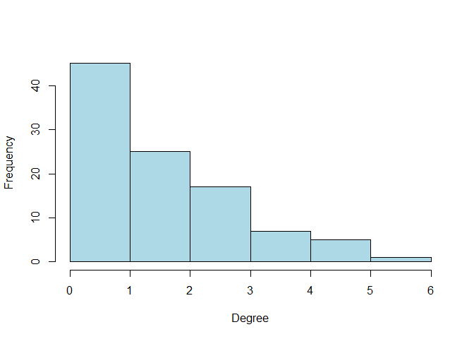

```r
# Degree 분포
hist(degree(g.er), col="lightblue",
     xlab="Degree", ylab="Frequency", main="")
```

- Transitivity = clustering coeffitient : 인접한 vertex가 연결되어 있을 확률(내 친구 a와 b가 친구일 확률)
- 네트워크의 조밀한 정도가 낮음(Low clustering)
- 노드 간의 평균거리가 짧음(short path 多)

```r
average.path.length(g.er)
```

```
## [1] 5.276511
```

```r
diameter(g.er) #최장 path 길이
```

```
## [1] 14
```

```r
transitivity(g.er)
```

```
## [1] 0.01639344
```

5.3 Generalized Random Graph Models

**Fixed degree sequence** - Nv = 8, d =2인 vertex가 4개, d = 3인 vertex가 4개인 그래프 g1, g2 생성 -> degree.sequence.game

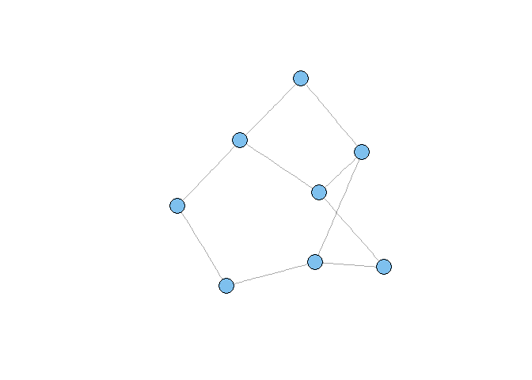

```r
degs <- c(2,2,2,2,3,3,3,3)
g1 <- degree.sequence.game(degs, method="vl")
g2 <- degree.sequence.game(degs, method="vl")
plot(g1, vertex.label=NA)
```

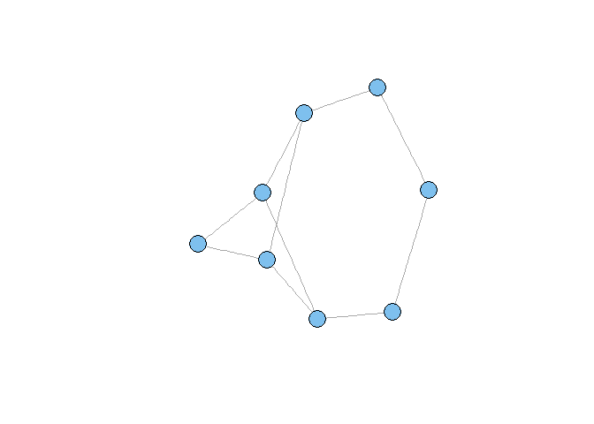

```r
plot(g2, vertex.label=NA)
```

```r
graph.isomorphic(g1, g2)
```

```
## [1] FALSE
```

```r
c(ecount(g1), ecount(g2), mean(degree(g1)), mean(degree(g2)))
```

```
## [1] 10.0 10.0  2.5  2.5
```

```r
data(yeast)
degs <- degree(yeast)
fake.yeast <- degree.sequence.game(degs, method=c("vl"))
all(degree(yeast) == degree(fake.yeast))
```

```
## [1] TRUE
```

- E, V, mean d 는 동일하나 diameter와 클러스터링 정도가 다름

```r
ecount(yeast)
```

```
## [1] 11855
```

```r
ecount(fake.yeast)
```

```
## [1] 11855
```

```r
vcount(yeast)
```

```
## [1] 2617
```

```r
vcount(fake.yeast)
```

```
## [1] 2617
```

```r
mean(degree(yeast))
```

```
## [1] 9.059992
```

```r
mean(degree(fake.yeast))
```

```
## [1] 9.059992
```

```r
diameter(yeast)
```

```
## [1] 15
```

```r
diameter(fake.yeast)
```

```
## [1] 7
```

```r
transitivity(yeast)
```

```
## [1] 0.4686178
```

```r
transitivity(fake.yeast)
```

```
## [1] 0.03968903
```

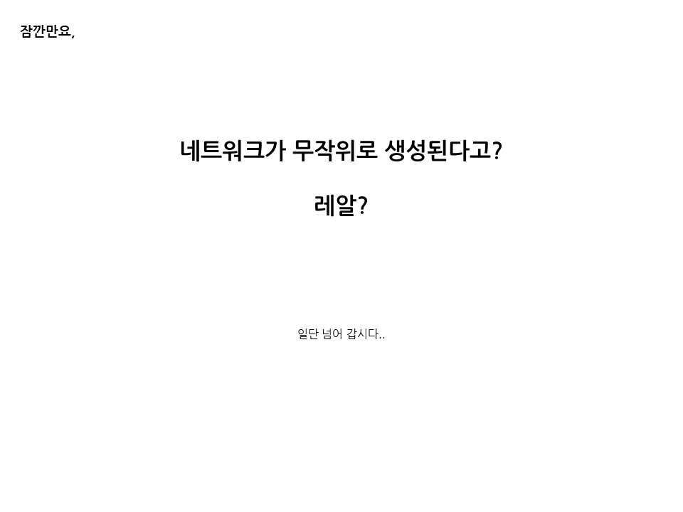

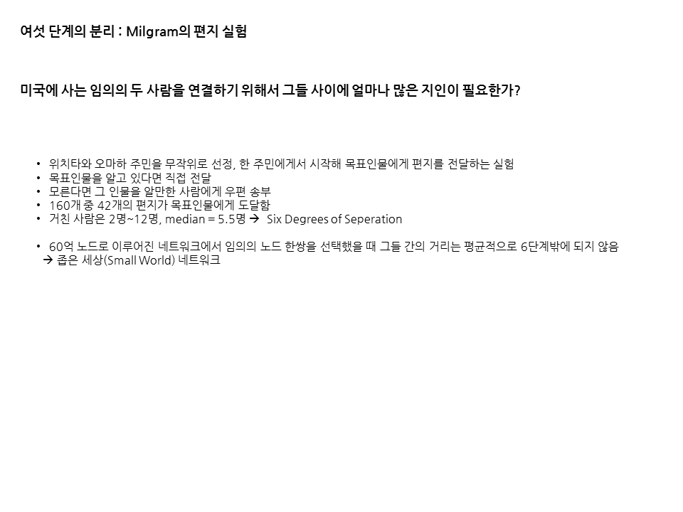

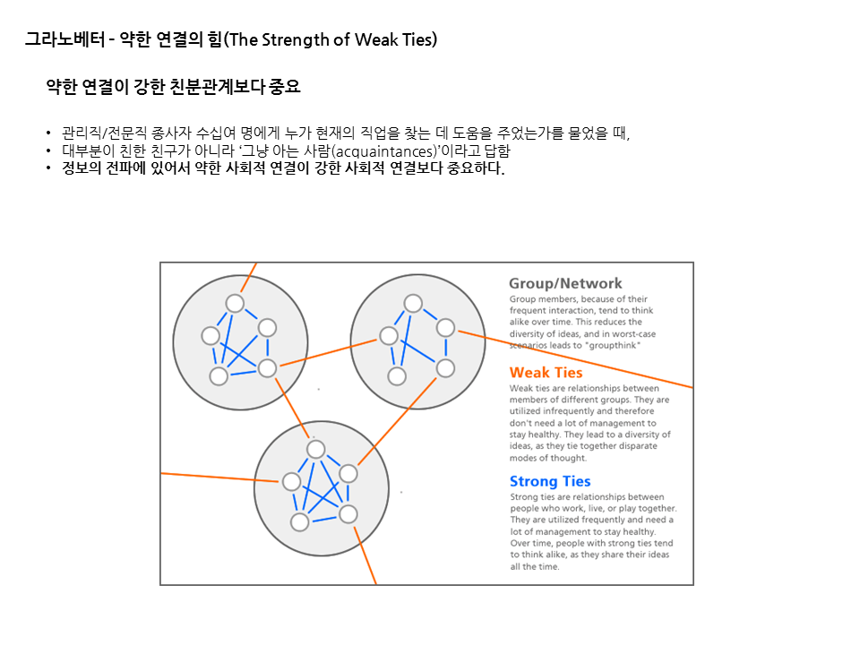

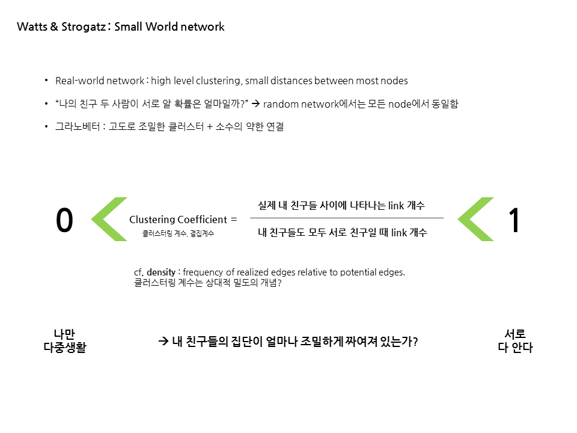

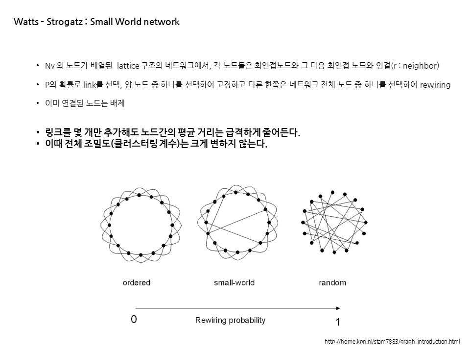

5.4 Network Graph Models Based on Mechanisms

5.4.1 Small-World Models

- R Code : watts.strogatz.game(dim, size, nei, p, loops = FALSE, multiple = FALSE)
- dim : the dimension of the starting lattice
- size: the size of the lattice along each dimension = Nv
- nei: the neighborhood within which the vertices of the lattice will be connected = r
- p: rewiring probability.
- loops / multiples : loop와 multiple edge의 허용 여부

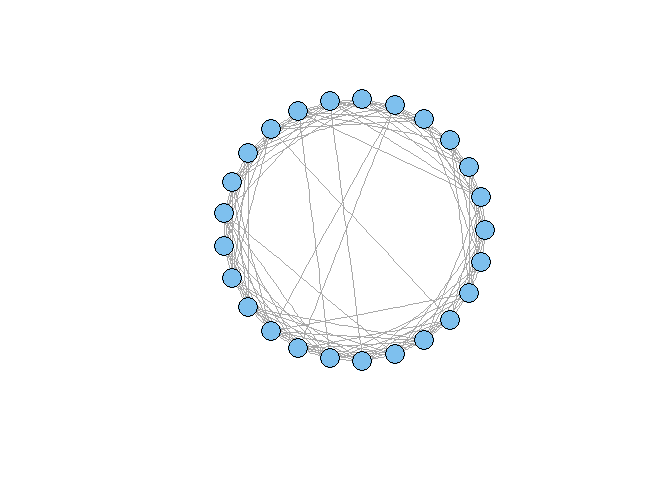

```r
#25개의 vertex, 5개 범위의 neighbor, 재배열확률 0.05를 가지는 small world network
g.ws <- watts.strogatz.game(1, 25, 5, 0.05)
plot(g.ws, layout=layout.circle, vertex.label=NA)
```

```r
vcount(g.ws)
```

```
## [1] 25
```

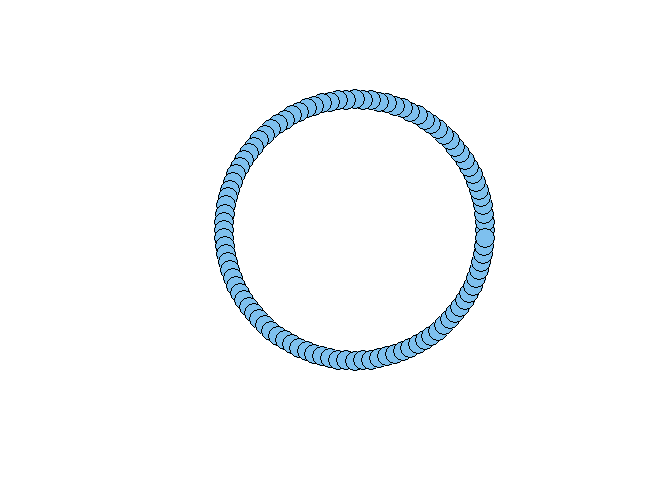

```r
g.lat100 <- watts.strogatz.game(1, 100, 5, 0)
plot(g.lat100, layout=layout.circle, vertex.label=NA)
```

```r
transitivity(g.lat100)
```

```
## [1] 0.6666667
```

```r
diameter(g.lat100)
```

```
## [1] 10
```

```r
average.path.length(g.lat100)
```

```
## [1] 5.454545
```

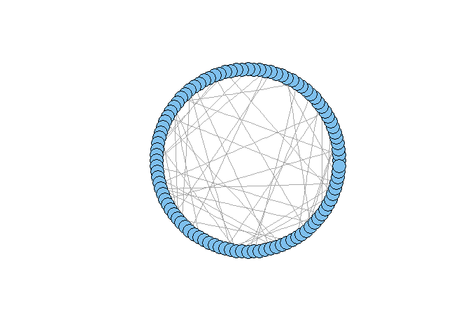

```r
g.ws100 <- watts.strogatz.game(1, 100, 5, 0.05)
plot(g.ws100, layout=layout.circle, vertex.label=NA)
```

```r
diameter(g.ws100)
```

```
## [1] 4
```

```r
average.path.length(g.ws100)
```

```
## [1] 2.669091
```

```r
transitivity(g.ws100)
```

```
## [1] 0.4864154
```

```r
ecount(g.lat100)
```

```
## [1] 500
```

```r
ecount(g.ws100)
```

```
## [1] 500
```

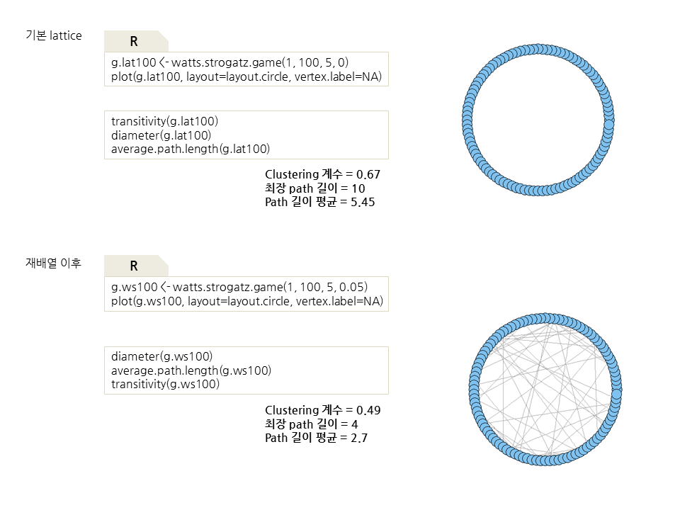

- Nv = 1000, r = 10인 small world network를 100번 생성 -> 클러스터링 계수와 평균 path 길이 변화의 양상을 확인
- -4 ≤ Log P ≤ -0.5 ( 0.0001 ≤ P ≤ -0.0.316)